# Ansible Lab 1

# Ansible Lab 1

Let’s Deploy a Virtual Machine with Vagrant and Provision it with Ansible| Bert Tejeda |

## Forward

Thank you for taking the time to read through this interactive document.

If you’re on the Windows platform, you’ll likely be accessing this file in its HTA format, which provides a superior experience for interaction with your workstation or laptop.

You can also output the resulting document as a .html file, which will allow you to open it in a web browser, but some caveats before you do that:

- If opening the document in a browser other than Internet Explorer, the shell interaction will **not** work at all
- If using Internet Explorer to open the .html file, should you choose to go that route, you’ll need to allow ActiveX controls once prompted

Moving on.

## How to Use this Document

Notice the navigation bar at the top.

There are several buttons, one of which reads Toggle Sidebar

Clicking it will reveal a navigation menu on the left. That’s pretty much all you need to know to get around this document.

There are also buttons that trigger commands for bootstrapping your system with the lab requirements.

Try them out!

## What This Lab Covers

Here’s what I will cover for Lab 1 of this Ansible tutorial series:

- What is ansible?
- How to install Ansible on Windows/Linux/MacOS
- What is Vagrant?
- How to prepare a test environment for Ansible using Vagrant

Let’s begin with the first topic: What is ansible?

## What is Ansible?

Ansible is a simple yet powerful tool for configuration management and orchestration of your infrastructure.

It speeds up installing software, configuring servers, and most importantly reduces manual, error-prone methods for managing modern infrastructure components.

It is also a great alternative to [Puppet](https://puppet.com/) and [Chef](https://www.chef.io/configuration-management/).

Both are similar tools to Ansible, but in my opinion Ansible is much easier to learn and master.

In a nutshell, [Ansible](https://www.ansible.com/) is:

- Like a higher-level, [idempotent](https://en.wikipedia.org/wiki/Idempotence#Computer_science_meaning) version of traditional shell scripts
- Much, much easier to rapidly develop and manage
- Lends itself to self-documenting development

### Terminology

Throughout the sections ahead, I’ll make reference to the following ansible terms:

- [inventory](https://docs.ansible.com/ansible/latest/user_guide/intro_inventory.html) - This is how ansible is made aware of the machines it is to manage
- [playbooks](https://docs.ansible.com/ansible/latest/user_guide/playbooks_intro.html) - This is the ansible version of a **bash** script
- [tasks](https://docs.ansible.com/ansible/latest/user_guide/playbooks_intro.html#tasks-list) - Think of this as you would a neatly commented step in a **bash** script, only far more superior in structure and clarity
- [variables](https://docs.ansible.com/ansible/latest/user_guide/playbooks_variables.html) - Just like **bash** variables, ansible stores repeatable information in these named constructs
- [facts](https://docs.ansible.com/ansible/latest/user_guide/playbooks_variables.html) - Very similar to variables, but think more of these as values that are automatically [derived](https://docs.ansible.com/ansible/latest/user_guide/playbooks_variables.html#information-discovered-from-systems-facts) from a machine or from a little bit of ansible [magic](https://docs.ansible.com/ansible/latest/user_guide/playbooks_variables.html#magic-variables-and-how-to-access-information-about-other-hosts)

For more information on ansible terms, consult the [Ansible Glossary](https://docs.ansible.com/ansible/latest/reference_appendices/glossary.html)

Next, let’s go over installing Ansible: Installation

## Installing Ansible

### Windows 7

Unfortunately, ansible is not yet supported on the *Windows 7 platform*

But don’t worry, you can still work *directly* with ansible by using a *virtual machine*.

For that, we’ll use *vagrant* to set up our virtual environment.

So if you’re on Windows 7, skip to the next section: Vagrant

If you’re on a Linux OS, installing ansible is fairly straight forward.

### Debian Systems

Installation on *Ubuntu* *16.04*:

```bash
sudo apt-get update
                sudo apt-get install -y curl software-properties-common || sudo apt-get install -y python-software-properties
                sudo apt-get -y autoremove
                sudo apt-get install -y --allow-unauthenticated python-setuptools python-dev libffi-dev libssl-dev git sshpass tree
                sudo apt-get -y install python-pip
                sudo pip install ansible cryptography
```

### RHEL Systems

Installation on *CentOS 7.x*, *Oracle Enterprise Linux 7.x*

```bash
rpm -ivh https://dl.fedoraproject.org/pub/epel/epel-release-latest-7.noarch.rpm
                yum install -y ansible
```

## What is Vagrant?

- [Vagrant](https://www.vagrantup.com/) is an open-source software product for building and maintaining portable virtual software development environments:
- Aims to simplify configuration management of virtualizations in order to increase development productivity
- Written in the Ruby programming language, and is thus highly extensible
- Supports numerous hypervisor [providers](https://www.vagrantup.com/docs/providers/), for example:
  - [VirtualBox](https://www.vagrantup.com/docs/virtualbox/)
  - [Hyper-V](https://www.vagrantup.com/docs/hyperv/)
  - [VMware](https://www.vagrantup.com/docs/vmware/)
  - [KVM/libvirt](https://github.com/vagrant-libvirt/vagrant-libvirt)
- It is a commandline tool
- Under the hood, it’s just sending commands to the corresponding hypervisor

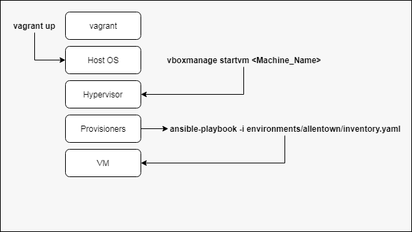

Vagrant ‘talking’ to Virtualbox

Think of it like this:

Vagrant is to **Virtual Machines** what [Docker](https://www.docker.com/) is to **Containers**

### Terminology

Throughout the sections ahead, I’ll make reference to the following terms:

- [box](https://www.vagrantup.com/docs/boxes.html) - This is vagrant terminology for *base image* A box is similar to a **.vmdk** file in **vmware**  
  In fact, you can convert a **.vmdk** file to vagrant **.box** format using `qemu-img convert`  
  The process is rather involved, and is essentially a conversion from **.vmdk** => **.qcow2** => **.box**
- **machine**: Virtual machine
- **machine definition**: A yaml-formatted text file that describes all aspects of the machine in question, e.g.:
  - name
  - groups
  - box
  - interfaces
  - disks
  - synced_folders
  - ip
  - vmem
  - vcpu: 1
  - provisioners
- sample machine definition
- [synced folder](https://www.vagrantup.com/docs/synced-folders/) - A directory on the hypervisor host shared with the guest, read more: [Synced Folders](https://www.vagrantup.com/docs/synced-folders/)
- **scratch playbook** - An ad-hoc playbook that is generated by the project, used as a scratch space for the ansible run.  
  Default location of the scratch playbook is: .vagrant/machines/{{ machine_name }}/provisioners/ansible/
- [provisioning](https://www.vagrantup.com/docs/provisioning/) - The post-boot phase wherein the machine is configured. Vagrant supports **many many** [provisioners](https://www.vagrantup.com/docs/provisioning/basic_usage.html).  
  This project makes use of the following provisioners:
  - [local](https://github.com/berttejeda/vagrant-venv/blob/master/lib/provision.rb) (This is a custom-built provisioner I implemented)
  - [shell](https://www.vagrantup.com/docs/provisioning/shell.html)
  - [ansible](https://www.vagrantup.com/docs/provisioning/ansible.html)

### Installation

To install vagrant:

1. Navigate to the vagrant downloads site: [vagrant downloads](https://www.vagrantup.com/downloads.html)
2. Once downloaded, launch the installer and follow the prompts
- The installer will make the `vagrant` command available through your *PATH* variable
- If upon installation, the `vagrant` command is not found, you may need to restart whatever terminal you have open, e.g. cmd, bash, iterm2, cygwin, etc

Some notes:

- The **Install Lab Requirements** button at the top is experimental and may not work, but you can give it a try (if you’re on Windows).  
  You’ll be presented with an installation menu from which you can choose to install vagrant.
- I **highly** recommend you install the following applications along with **vagrant**:
  - [cmder](http://cmder.net/)  
    The commandline experience presented through it more closely matches a posix-compliant operating environment
  - [Sublime Text 3](https://www.sublimetext.com/3)  
    Forget Notepad++, just throw it away. This one is king!

Once you’ve installed the tools, proceed to the next section: Preparing Your Lab

## Lab Prep

To follow along, you’ll need the following:

1. [vagrant](https://www.vagrantup.com/downloads.html)
2. [virtualbox](https://www.virtualbox.org/)
3. [git](https://git-scm.com/download/win)
4. [vagrant-venv](https://github.com/berttejeda/vagrant-venv.git)
   - You can also obtain a copy of the [vagrant-venv](https://github.com/berttejeda/vagrant-venv.git) repository via:
     - `git clone https://github.com/berttejeda/vagrant-venv.git`  
       or
     - by navigating to the [repository](https://github.com/berttejeda/vagrant-venv.git) in your browser and downloading a zip archive of the files

Some notes:

- The **Install Lab Requirements** button at the top is experimental and may not work, but you can give it a try.

Once you’ve met all requirements, we can proceed in preparing your local lab environment.

Moving along ☞

## Initializing virtual machines using vagrant

1. Again, you’ll need the **vagrant-venv** source files to follow along, so make sure you’ve obtained the files.
2. From your terminal, navigate to the location where you downloaded the project files, and `cd` to the directory:
   - `cd vagrant-venv`
3. List the available environments
   - `vagrant environment list`  
     You should see only one: *environments/contoso*
4. Create the ansible **inventory** file for the **contoso** environment
   - `vagrant inventory create contoso`
5. Review the status of the **contoso** virtual machines
   - `vagrant status`  
     You should see something similar to:

[figure not shown]

6. Now that you are aware of the available machines, let’s boot up the **web01.contoso.com** host:
   - `vagrant up web01.contoso.com`  
     You should see something similar to:

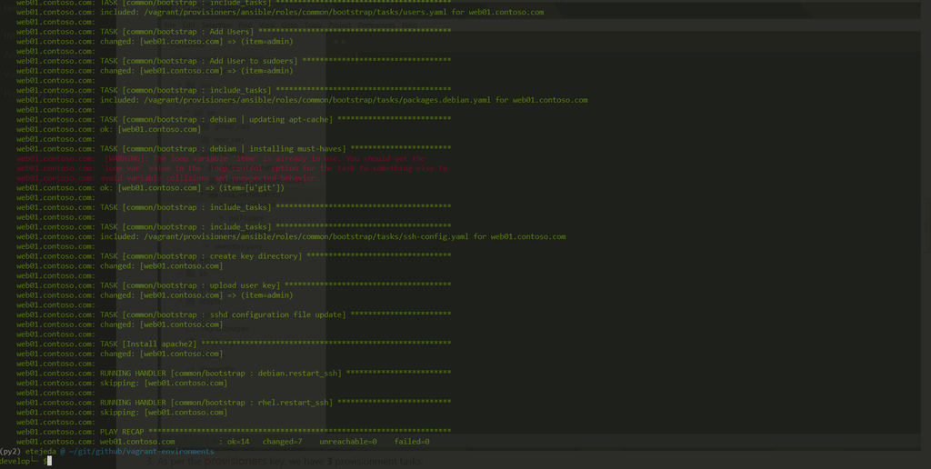

7. You’ll observe that vagrant takes the following actions:
   - Checks for the **machine** **box** as specified in the **machine definition**
   - Downloads the **box** locally if necessary  
     i.e., if the box has already been downloaded, vagrant will happily use the cached version
   - Boots up the **machine** using the **box** image
   - Checks if the initial **provisioning** tasks have been run against the **machine**,  
     and if not, will run the initial provisionment task(s)
8. Again, vagrant is simply ‘talking’ to the underlying hypervisor and cycling through several phases of the machine boot up process, as illustrated:

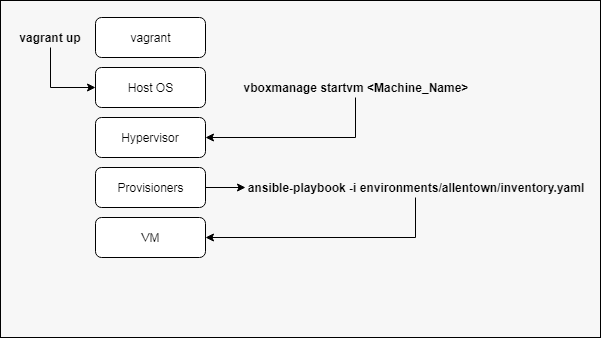

## Provisioning your machines using ansible

The machine **web01.contoso.com** should be booted and ready for action 😎

Let’s modify the provisionment steps for this machine.

As Follows ☞

1. From your terminal, open the current directory as a *Project Tree* in Sublime Text 3:
   - `subl .`  
     Note: I’m assuming you’ve chosen to install **Sublime Text 3**, which includes a step that adds a custom function `subl` to your *~/bash.profile*.  
     Again, you can install Sublime Text 3 via the **Install Lab Requirements** button at the top  
     You can also verify that the `subl` function is available to you by entering `type subl` in your terminal
2. Review the **web01.contoso.com** machine definition file: *environments/contoso/machines/web-servers/web01.contoso.com.yaml*

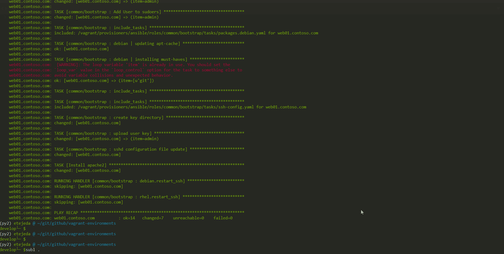

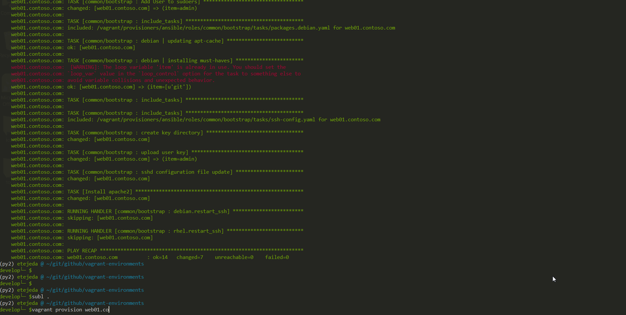

## Writing ansible playbooks using Sublime 3 Text Editor

The fun starts when you learn your way around ansible **playbooks**!

Let’s create some of these and reference them in the web01.contoso.com machine definition file:

As Follows ☞

- Create a folder path **web01.contoso.com/playbooks** *alongside* the web01.contoso.com definition file:
  - `mkdir -p environments/contoso/machines/web-servers/web01.contoso.com/playbooks`
- Using Sublime Text Editor 3, create a playbook under this path named **hello.yaml**
  - `subl environments/contoso/machines/web-servers/web01.contoso.com/playbooks/hello.yaml`
- Add a debug task to the playbook that prints out a simple message:

```yaml
                - name: debug | Say Hello!
                  debug:
                    msg: |
                      Hello from the imported playbook!
```

- Add an include_tasks task to the **web01.contoso.com** machine definition referencing this playbook:

```yaml
                - name: includes | Include Tasks from the Hello Playbook
                  include_tasks: web01.contoso.com/playbooks/hello.yaml
```

- Manually invoke the provisionment steps:
  - `vagrant provision web01.contoso.com`  
    As illustrated:

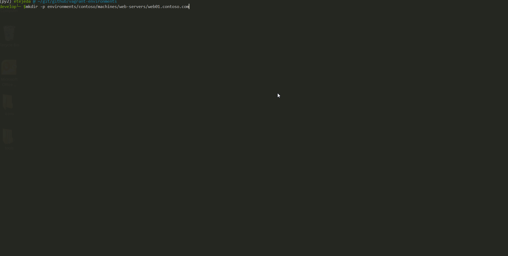

## Testing your playbooks using a virtual machine

At this point, you don’t need the vagrant command to thoroughly test your ansible playbooks.

You can ssh to the **web01.contoso.com** machine and play with the **scratch playbook**

As Follows ☞

1. SSH to the **web01.contoso.com** machine
   - `vagrant ssh web01.contoso.com`
2. chdir to the **/vagrant** directory (by default, vagrant will create this shared folder between guest and host; maps to the vagrant project folder, read more: [synced folder](https://www.vagrantup.com/docs/synced-folders/))
   - `cd /vagrant`
3. Call the playbook via the `ansible-playbook` command
   - `ansible-playbook -i environments/contoso/inventory.yaml -c local ./.vagrant/machines/web01.contoso.com/provisioners/ansible/playbook.scratch.yaml`

Notice how I forced ansible to use a local connection to the host (`-c local`).

If you want ansible to utilize passwordless ssh connection for the playbook tasks, you’ll need to initialize ssh keys for passwordless connectivity:

As Follows ☞

- Generate an ssh key
  - `ssh-keygen -f ~/.ssh/id_rsa -t rsa -N ''`
- Add authorized key locally
  - `cat ~/.ssh/id_rsa.pub >> ~/.ssh/authorized_keys`
- Apply appropriate file permissions
  - `if test -f ~/.ssh/config;then chmod 600 ~/.ssh/config;fi`
  - `chmod 700 ~/.ssh && chmod 400 ~/.ssh/id_rsa`

This concludes lab1.

In lab2, we’ll be converting a complicated bash shell script into an Ansible Playbook.

The lab will cover:

- Playbooks and Tasks
- Templates and Handlers
- Variables & Facts
- Task Blocks